# Australian Resource Export Volumes — Quarterly Nowcast

resourcetracker · per-commodity tonnage nowcast (iron_ore, coal)

2026-05-19

## Top line

- **IRON_ORE** Jun 2026: **234.9 Mt** (80% CI 231.2 – 237.9). Quarter 54% observed. Change: -2.1 Mt (-0.9%) vs the run 1h ago.
- **COAL** Jun 2026: **87.9 Mt** (80% CI 86.5 – 89.9). Quarter 54% observed. Change: +0.0 Mt (+0.0%) vs the run 1h ago.

## Headline: current-quarter nowcasts (Mt)

- **IRON_ORE** (Jun 2026): **234.9 Mt** (80% CI: 231.2 – 237.9 Mt). Share observed: 54%.
- **COAL** (Jun 2026): **87.9 Mt** (80% CI: 86.5 – 89.9 Mt). Share observed: 54%.

## Nowcast vs recent actuals

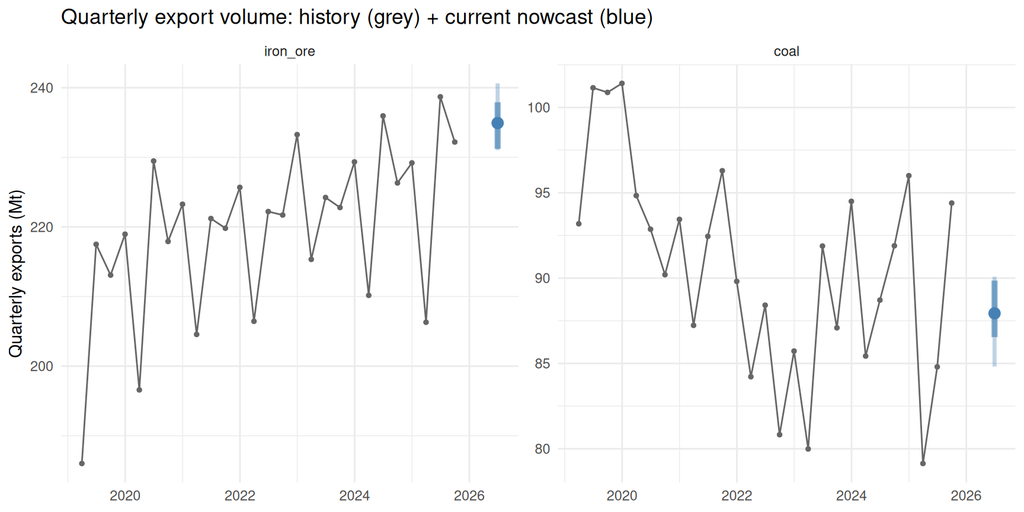

## Bridge diagnostics

★ marks the production-deployed spec per commodity (best of the candidate set + combinations by backtest RMSE). `R²` is in-sample, `R²_oos` is walk-forward out-of-sample. `p(β_lag4=1)` is the Wald-test p-value for the YoY-on-YoY restriction (NA for `bojo`, which imposes it; `equal_avg` and `inv_mse` are combination forecasts and have no in-sample β). `RMSE/naive` < 1 means the spec beats the seasonal random walk.

| ★ | commodity | spec | R² | R²_oos | β_T (se) | β_lag4 | p(β_lag4=1) | rmse_valid | RMSE/naive |
| --- | --- | --- | --- | --- | --- | --- | --- | --- | --- |
|  | iron_ore | aggregate | 0.91 | 0.83 | 0.475 (se 0.094) | 0.960 | 0.359 | 4.83 | 0.84 |
| ★ | iron_ore | bojo | 0.61 | 0.85 | 0.502 (se 0.094) |  |  | 4.49 | 0.78 |
|  | iron_ore | equal_avg |  | 0.84 |  |  |  | 4.60 | 0.80 |
|  | iron_ore | inv_mse |  | 0.84 |  |  |  | 4.59 | 0.79 |
|  | iron_ore | midas | 0.92 | 0.84 | 0.465 (se 0.082) | 0.978 | 0.711 | 4.62 | 0.80 |
| ★ | coal | aggregate | 0.87 | 0.85 | 0.774 (se 0.092) | 0.732 | 0.000 | 2.14 | 0.50 |
|  | coal | bojo | 0.85 | 0.79 | 0.883 (se 0.099) |  |  | 2.51 | 0.59 |
|  | coal | equal_avg |  | 0.83 |  |  |  | 2.27 | 0.53 |
|  | coal | inv_mse |  | 0.83 |  |  |  | 2.25 | 0.53 |
|  | coal | midas | 0.86 | 0.80 | 0.765 (se 0.106) | 0.748 | 0.000 | 2.45 | 0.58 |

## PortWatch tonnage trend

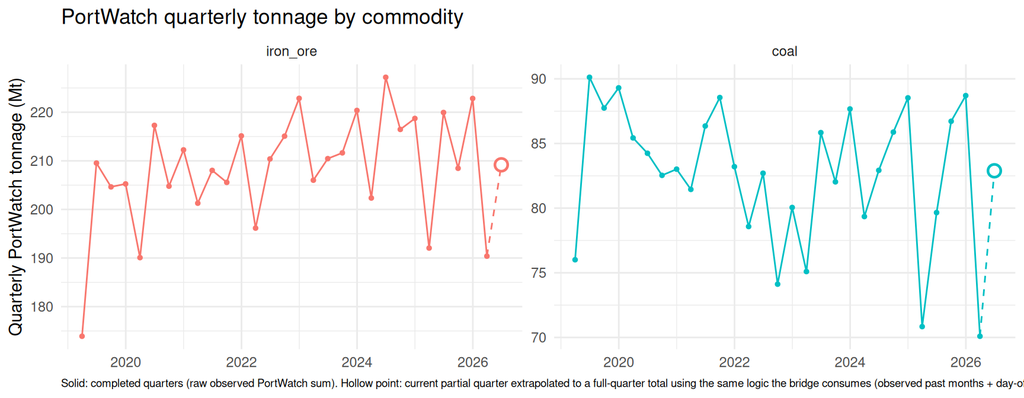

## Change since last run

Same-quarter run-over-run delta. Drops rows for any commodity whose current quarter has no prior nowcast.

| commodity | quarter_end | prior_Mt | now_Mt | delta_Mt | delta_pct | hours_since |
| --- | --- | --- | --- | --- | --- | --- |
| iron_ore | 2026-06-30 | 237.05 | 234.92 | -2.13 | -0.9 | 1.1 |
| coal | 2026-06-30 | 87.94 | 87.94 | 0.00 | 0.0 | 1.1 |

## Methodology footnote

For each commodity $c \in \{\text{iron\_ore}, \text{coal}\}$, quarterly frequency:

- $V_{c,Q}$ = DISR Resources & Energy Quarterly Table 16, physical tonnage (Mt) by commodity. Coal is metallurgical + thermal summed.
- $T^{SA}_{c,Q}$ = STL seasonally-adjusted quarterly PortWatch tonnage, summed across ports whose `commodity_class` matches $c$. Tanker tonnage at LNG-whitelisted ports routes to `lng` at ingestion but is then scoped out of the bridge panel (LNG was dropped 2026-04-21 after zero-correlation finding).
- Fit window: 2019-Q1 → 2023-Q4 (RHS-constrained by PortWatch coverage). Validation: 2024-Q1 onward.
- Newey-West HAC standard errors with `lag = 1` at quarterly frequency.
- Uncertainty bands: residual bootstrap, scaled by $\sqrt{1 - \text{share\_observed}}$ so bands collapse as the current quarter fills in.